# Taller Evaluable 1 2020, FIFA 2019

mat3: Laura ; Lidia

3/12/2020

# Taller evaluable datos FIFA 2020

Registraros en kaggle y bajaros el data set [FIFA 2020 Datos completos 2015 a 2020](https://www.kaggle.com/stefanoleone992/fifa-20-complete-player-dataset). Guarda los datos en una carpeta FIFA2020.

Las siguientes preguntas con relativas al data set `players_20.csv`

## Pregunta 0

Explica el data set y de qué tipo son cada una de las variables y en qué tipo de fichero están guardadas. Carga los datos en un data frame con `read.csv` y explica las clases de cada columna de datos. Explica el parámeto `encoding`.

```r
datos = read.csv("FIFA2020/players_20.csv", encoding="UTF-8")
head(datos, 5)
```

```
##   sofifa_id
## 1    158023
## 2     20801
## 3    190871
## 4    200389
## 5    183277
##                                                              player_url
## 1               https://sofifa.com/player/158023/lionel-messi/20/159586
## 2 https://sofifa.com/player/20801/c-ronaldo-dos-santos-aveiro/20/159586
## 3  https://sofifa.com/player/190871/neymar-da-silva-santos-jr/20/159586
## 4                  https://sofifa.com/player/200389/jan-oblak/20/159586
## 5                https://sofifa.com/player/183277/eden-hazard/20/159586
##          short_name                           long_name age        dob
## 1          L. Messi      Lionel Andrés Messi Cuccittini  32 1987-06-24
## 2 Cristiano Ronaldo Cristiano Ronaldo dos Santos Aveiro  34 1985-02-05
```

[output cut: 123 more lines]

## Pregunta 1

¿Qué clubs tienen a los 10 mejores jugadores según su “overall”?

```r
sort_overall =sort(datos$overall,decreasing=TRUE)[1:10]
clubs = datos[datos$overall %in% sort_overall,]$club
clubs = as.vector(clubs)
clubs = clubs[!duplicated(clubs)]
```

```r
clubs = datos[order(datos$overall, decreasing=TRUE)[1:10], "club"]
clubs = unique(clubs)
clubs
```

```
## [1] FC Barcelona        Juventus            Paris Saint-Germain
## [4] Atlético Madrid     Real Madrid         Manchester City
## [7] Liverpool
## 698 Levels:  SSV Jahn Regensburg 1. FC Heidenheim 1846 ... Zaglebie Lubin
```

## Pregunta 2

Crea un dataframe “sub_fifa20” que contenga a los jugadores de los clubs encontrados en el ejercicio anterior.

```r
sub_fifa20 =datos[datos$club %in% clubs, ]
```

## Pregunta 3

Calcula la media y desviación típica muestral de los sueldos de los jugadores por equipo del dataframe sub_fifa20.

```r
aggregate(wage_eur~club,data=sub_fifa20,FUN= function(x) {c(media=mean(x),sd=sd(x))})
```

```
##                  club wage_eur.media wage_eur.sd
## 1     Atlético Madrid       44848.48    31608.07
## 2        FC Barcelona      150000.00   130914.81
## 3            Juventus      113636.36    77462.42
## 4           Liverpool       80818.18    67478.91
## 5     Manchester City      120727.27    99257.01
## 6 Paris Saint-Germain       72606.06    65992.40
## 7         Real Madrid      162242.42   111794.46
```

```r
f = function(x) {c(mean(x),sd(x))}
tabla = aggregate(wage_eur~club,data=sub_fifa20,FUN=f)
tabla2 = data.frame(Club=tabla$club, Sueldo_medio = tabla$wage_eur[, 1], Desv_tip_mues = tabla$wage_eur[, 2])
tabla2
```

```
##                  Club Sueldo_medio Desv_tip_mues
## 1     Atlético Madrid     44848.48      31608.07
## 2        FC Barcelona    150000.00     130914.81
## 3            Juventus    113636.36      77462.42
## 4           Liverpool     80818.18      67478.91
## 5     Manchester City    120727.27      99257.01
## 6 Paris Saint-Germain     72606.06      65992.40
## 7         Real Madrid    162242.42     111794.46
```

## Pregunta 4

Discretiza la variable age de sub_fifa20 en los 3 niveles siguientes: “freshman”, “junior”, “senior”, según los cortes por defecto. La variable resultante age_Level tiene que ser un factor ordenado en orden creciente de edad.

```r
age_Level=ordered(cut(sub_fifa20$age,breaks=3),labels=c("freshman","junior","senior"))
head(age_Level)
```

```
## [1] junior senior junior junior junior junior
## Levels: freshman < junior < senior
```

## Pregunta 5

¿Qué club tiene a más jugadores en el nivel “freshman” calculado en el ejercicio anterior?

```r
sub_fifa20$age_level = age_Level
aggregate(age_level~club,data=sub_fifa20,FUN=function(x) sum(x=='freshman'))
```

```
##                  club age_level
## 1     Atlético Madrid        19
## 2        FC Barcelona        21
## 3            Juventus        14
## 4           Liverpool        18
## 5     Manchester City        23
## 6 Paris Saint-Germain        19
## 7         Real Madrid        16
```

```r
aggregate(age_level~club,data=sub_fifa20,FUN=function(x) table(x)["freshman"] )
```

```
##                  club age_level
## 1     Atlético Madrid        19
## 2        FC Barcelona        21
## 3            Juventus        14
## 4           Liverpool        18
## 5     Manchester City        23
## 6 Paris Saint-Germain        19
## 7         Real Madrid        16
```

## Pregunta 6

¿Cuántas nacionalidades hay entre todos los jugadores de sub_fifa20? ¿Qué club tiene mayor cantidad de nacionalidades?

```r
length(unique(sub_fifa20$nationality))
```

```
## [1] 36
```

```r
nationalities_per_club = aggregate(nationality~club,data=sub_fifa20,FUN=function(x) length(unique(x)))
nationalities_per_club[nationalities_per_club$nationality==max(nationalities_per_club$nationality),]
```

```
##              club nationality
## 1 Atlético Madrid          15
## 4       Liverpool          15
```

## Pregunta 7

Calcula mediante un diagrama de tarta la proporción de jugadores de cada nacionalidad en cada club

[figure not shown]

```r
par(mfrow=c(4,2))
for(club in clubs){
  nationalities = sub_fifa20[sub_fifa20$club %in% c(club), ]$nationality
  nationalities = as.vector(nationalities)
  pie(table(nationalities), main=paste0("Proporción de nacionalidades en el", club))
}
par(mfrow=c(1,1))
```

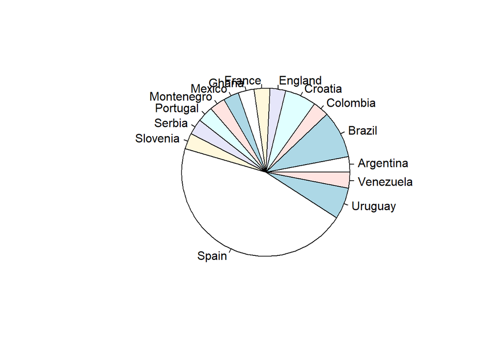

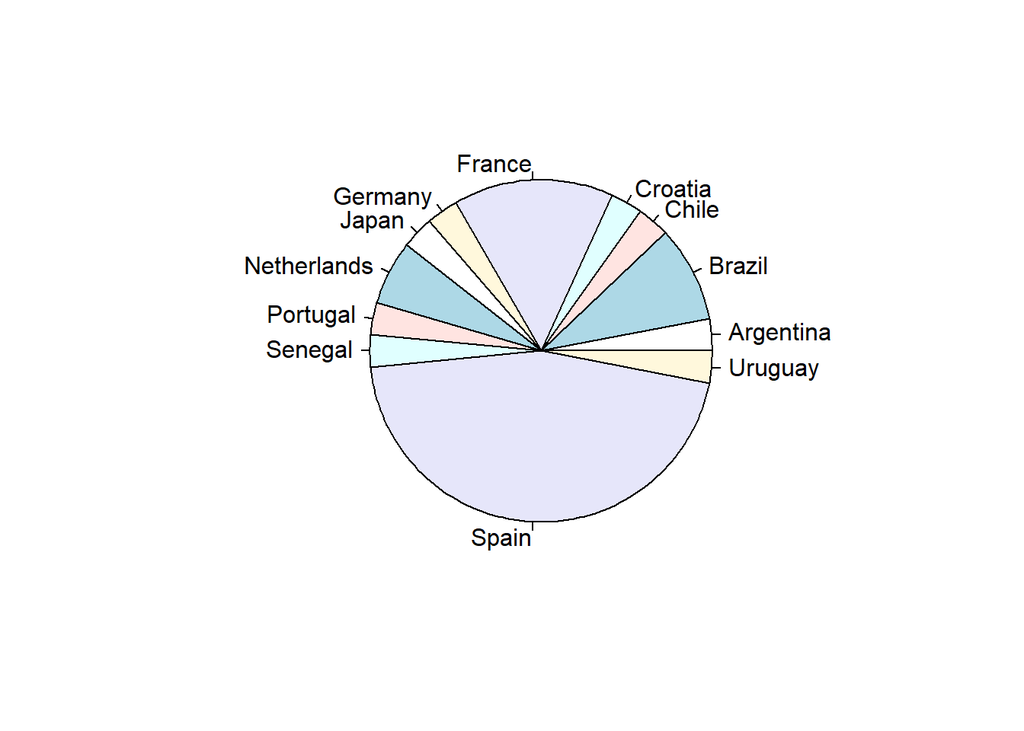

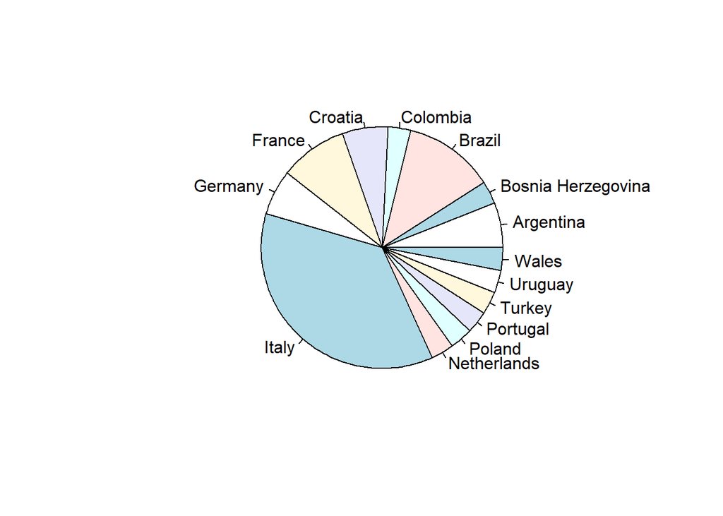

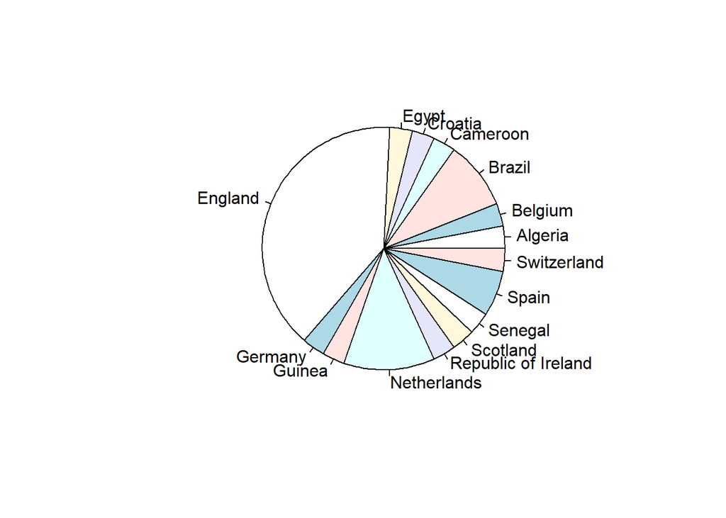

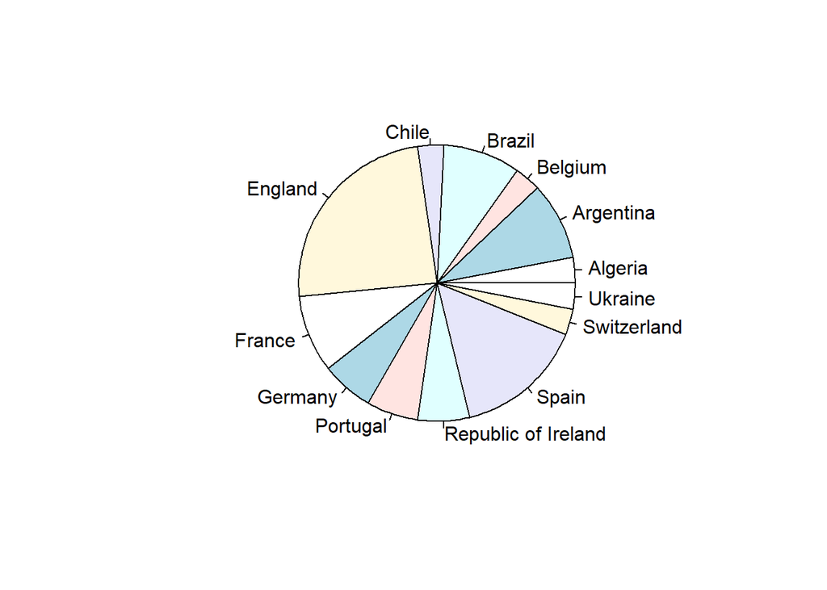

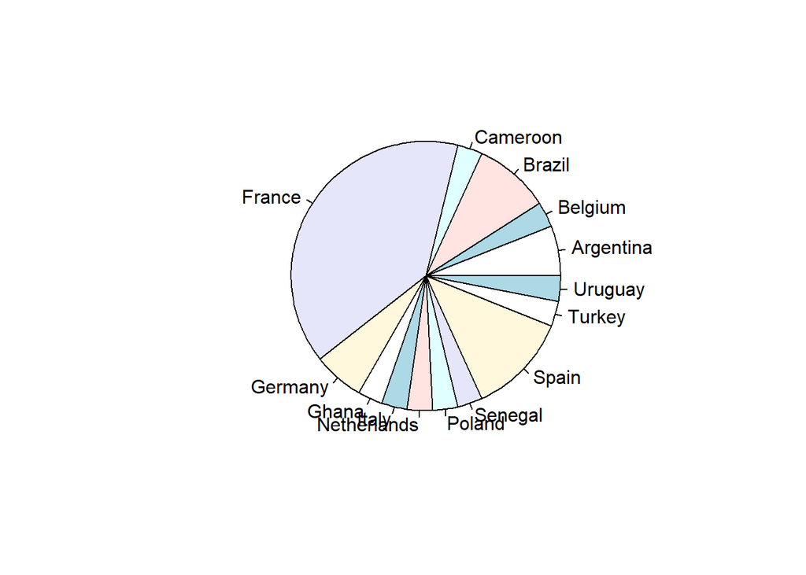

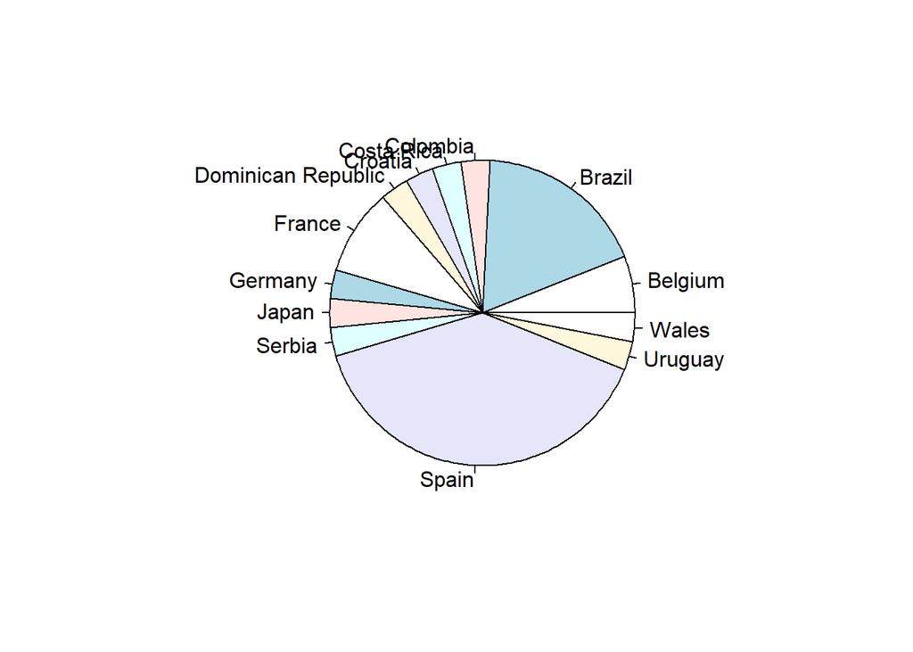

```
##                  club nationality
## 1     Atlético Madrid        NULL
## 2        FC Barcelona        NULL
## 3            Juventus        NULL
## 4           Liverpool        NULL
## 5     Manchester City        NULL
## 6 Paris Saint-Germain        NULL
## 7         Real Madrid        NULL
```

```r
aggregate(nationality~club, sub_fifa20, FUN =function(x) pie(table(droplevels(x))))
```

## Pregunta 8

Encuentra la función (lineal, exponencial o potencial) que mejor describe la dependencia funcional del sueldo de los jugadores en función de la variable overall en el dataframe sub_fifa20. Representa dicha función junto con los puntos (overall, sueldo) en escala lineal.

```r
summary(lm(sub_fifa20$wage_eur~sub_fifa20$overall))$r.squared
```

```
## [1] 0.657717
```

```r
summary(lm(log10(sub_fifa20$wage_eur)~sub_fifa20$overall))$r.squared
```

```
## [1] 0.8816264
```

```r
summary(lm(log10(sub_fifa20$wage_eur)~log10(sub_fifa20$overall)))$r.squared
```

```
## [1] 0.8859737
```

```r
lm(log10(sub_fifa20$wage_eur)~log10(sub_fifa20$overall))
```

```
##
## Call:
## lm(formula = log10(sub_fifa20$wage_eur) ~ log10(sub_fifa20$overall))
##
## Coefficients:
##               (Intercept)  log10(sub_fifa20$overall)
##                    -14.29                      10.10
```

$$\textrm{wage_eur}(\textrm{overall}) = 10^{-14.29} \cdot \textrm{overall}^{10.10}$$

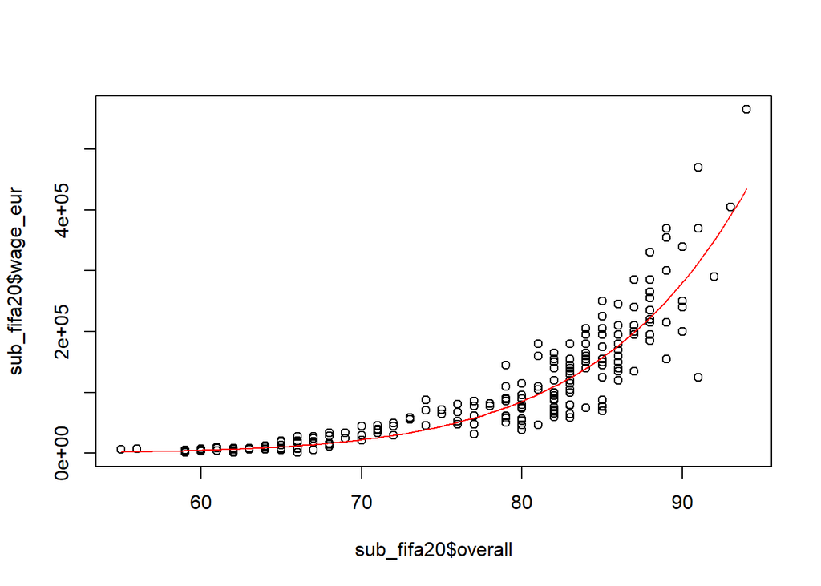

```r
plot(sub_fifa20$overall, sub_fifa20$wage_eur)
curve(10^-14.29*x^10.10, add = TRUE, col="red")
```